# Word embedding spaces

2022-04-03

## Syllabus

- Static word embeddings
  - Frequency based methods, word2vec, GloVe, fastText, evaluation of embeddings
- Contextual word embeddings
  - ELMo, **Transformers** and attention, BERT, sentence embeddings, contrastive learning
- Additional topics
  - Geometry of the embedding space, bias, sentiment, multilingual embeddings
- Topological data analysis
  - Hyperbolic embeddings, singularities and topological polysemy

## Motivation: Winograd schemas

- The trophy doesn’t fit into the brown suitcase because it’s too large.
- The trophy doesn’t fit into the brown suitcase because it’s too small.

*Task:* Co-reference resolution

## Motivation: Winograd schemas

- The city councilmen refused the demonstrators a permit because they feared violence.
- The city councilmen refused the demonstrators a permit because they advocated violence.

*Task:* Co-reference resolution

- easy for humans to solve
- difficult for computers
  - solution relies on real-world knowledge and common sense reasoning

## Motivation: Winograd schemas

- I put the cake away in the refrigerator. It has a lot of butter in it.
- I put the cake away in the refrigerator. It has a lot of leftovers in it.

## Motivation: Garden-path sentences

- The old man the boat.
- The complex houses married and single soldiers and their families.
- The horse raced past the barn fell.

## Methods

“You shall know a word by the company it keeps.” (J. R. Firth, 1957)

(Jurafsky and Martin 2009)

[interactive chart not shown]

## Applications of word embeddings

- *Word-sense induction* (WSI) or word-sense discrimination: task is the identification of the senses/meanings of a word
- Output: clustering of contexts of the target word, or a clustering of words related to the target word

**Example:**

- target word “cold”
- collection of sentences:
  - “I caught a cold.”
  - “The weather is cold.”
  - “The ice cream is cold.”
- *Word-sense disambiguation* (WSD): relies on a predefined sense inventory, and the task is to solve the ambiguity in the context
- Output: identifying which sense of a word is used in a sentence

## Part-of-speech tagging

- grammatical tagging: decide which part of speech (noun, verb, article, adjective, preposition, pronoun, adverb, conjunction, and interjection) in a text/corpus belongs to
- this might depend both on the definition of the word and its context, and in language a large portion of word-forms are ambiguous
  - Example from wikipedia: “dogs” usually is a plural noun, but can also be a verb as in the sentence “The sailor dogs the hatch.”
- sub-categories for PoS tagging:
  - for nouns, the plural, possessive, and singular forms can be distinguished.
  - “case” (role as subject, object, etc.), grammatical gender, and so on
  - verbs are marked for tense, aspect, and other things
- Example where order matters:
  - “can of fish”
  - “we can fish”

## Text classification

- Document classification: spam / not spam
- Review classification: positive / negative
- Sentiment
- single-label classification / multi-label classification

## Generative and Discriminative Models

- Generative models:
  - learn undelying data distribution \(P(x, y) = P(x | y) \cdot P(y)\)
  - prediction: given an input \(x\), pick a class with the highest joint probability \(y = \mathop{\mathrm{argmax}}_{k} P(x | y = k) \cdot P(y = k)\)
    - maximum a posteriori (MAP) estimate
- Discriminative models:
  - learn the boundaries between classes (i.e. learn how to use the features)
  - prediction: given an input \(x\), pick a class with the highest conditions probability \(y = \mathop{\mathrm{argmax}}_{k} P(y = k | y)\)
    - Maximum Likelihood Estimate (MLE) of parameters

*Bag of Words (BoW) assumption*: word order does not matter

## word2vec, GloVe, fastText

word2vec: (Mikolov, Chen, et al. 2013; Mikolov, Sutskever, et al. 2013)

## Contextual word embeddings

- I’m going to the bank to withdraw some money.
- We’re sitting on the river bank with some friends.

## Recurrent methods: ELMo

## **Transformers**

- attention

## Bidirectional Encoder Representations from Transformers (BERT)

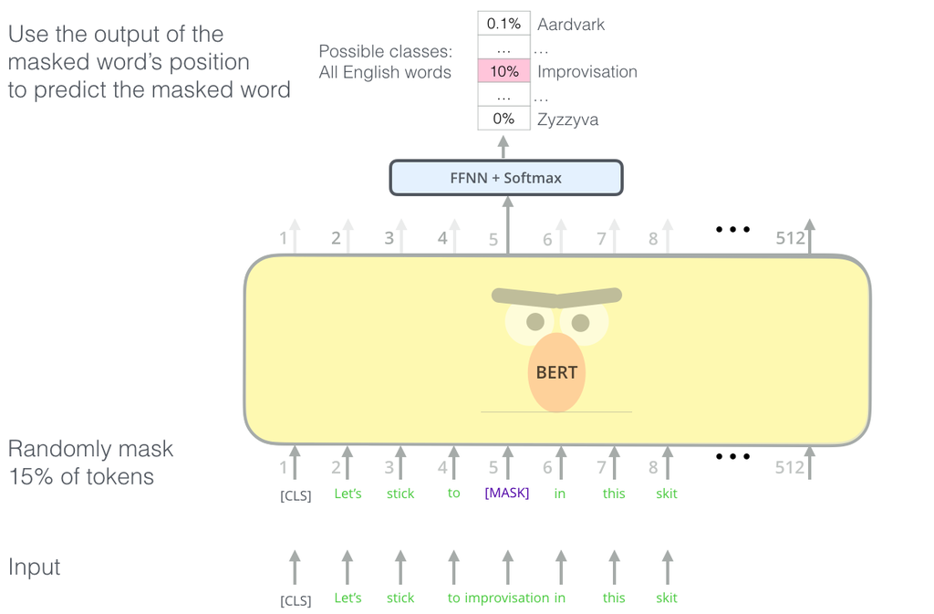

https://jalammar.github.io/illustrated-bert/

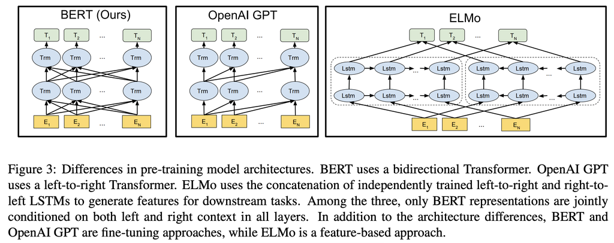

(Devlin et al. 2018)

## Huggingface transformers

https://huggingface.co/distilbert-base-uncased

## Sentence embeddings

- Sentence-BERT
  - sentence-pair regression tasks like semantic textual similarity (STS)

## Singularities

- the *manifold hypothesis* does not hold at all points of certain static word embeddings

(Jakubowski, Gasic, and Zibrowius 2020)

## Thank you!

## Organisation

- Schedule: See [Google sheet](https://docs.google.com/spreadsheets/d/1s-pxSBL0pK5RN5ny5IiSsXUL9i8nQM7iIx_j_euDf08/edit?usp=sharing)
- Each week talks by students (1 or 2 speakers per session, 70 minutes in total)
  - there should be enough time for questions and a discussion
- Guest lecture ?
- The final grade is based on your presentation
- Hand in your extended abstract (ideally .tex, .bib files and compiled .pdf; **maximum** 2 pages with references) via ILIAS

## References

Devlin, Jacob, Ming-Wei Chang, Kenton Lee, and Kristina Toutanova. 2018. “ BERT: Pre-Training of Deep Bidirectional Transformers for Language Understanding.” *CoRR* abs/1810.04805. http://arxiv.org/abs/1810.04805.

Jakubowski, Alexander, Milica Gasic, and Marcus Zibrowius. 2020. “Topology of Word Embeddings: Singularities Reflect Polysemy.” In *Proceedings of the Ninth Joint Conference on Lexical and Computational Semantics*, 103–13. https://arxiv.org/abs/2011.09413.

Jurafsky, Daniel, and James H. Martin. 2009. *Speech and Language Processing*. MIT Press.

Mikolov, Tomás, Kai Chen, Greg Corrado, and Jeffrey Dean. 2013. “Efficient Estimation of Word Representations in Vector Space.” In *1st International Conference on Learning Representations, ICLR 2013, Scottsdale, Arizona, USA, May 2-4, 2013, Workshop Track Proceedings*, edited by Yoshua Bengio and Yann LeCun. http://arxiv.org/abs/1301.3781.

Mikolov, Tomás, Ilya Sutskever, Kai Chen, Greg Corrado, and Jeffrey Dean. 2013. “Distributed Representations of Words and Phrases and Their Compositionality.” *CoRR* abs/1310.4546. http://arxiv.org/abs/1310.4546.